# Esmerald. Experience sampling made easy.

M Schmettow

19/02/2021

```r
library(tidyverse)
library(lubridate)
library(esmerald)
```

# Data preparation

## Importing state data

Character vector of csv files

```r
csv <- dir("../inst/extdata/",full.names = T)[2:9]
```

Reading a single file

```r
ESM_1 <-
  read_ethica_csv("../inst/extdata/survey_responses_5716.csv")
```

The result is a table of class *tbl_esm*.

```r
class(ESM_1)
```

```
## [1] "tbl_esm_eth" "tbl_df"      "tbl"         "data.frame"
```

But the fact that we use S3 classes shouldn’t bother you. It just makes it easier for us to create a convenient interface. For example, if you just call the ESM_1 object like this:

```r
ESM_1
```

you get a useful summary of the data set:

```
## # A tibble: 336 x 10
##      Obs Activity Part      Device       T_Scheduled         T_Issued
##    <int>    <dbl> <chr>     <chr>        <dttm>              <dttm>
##  1     1     5716 User #25~ 5a0a109eb4e~ 2020-04-12 10:49:08 2020-04-12 10:54:15
##  2     2     5716 User #25~ 5a0a109eb4e~ 2020-04-12 10:49:08 2020-04-12 10:54:15
##  3     3     5716 User #25~ 5a0a109eb4e~ 2020-04-12 10:49:08 2020-04-12 10:54:15
##  4     4     5716 User #25~ 5a0a109eb4e~ 2020-04-12 10:49:08 2020-04-12 10:54:15
##  5     5     5716 User #25~ 5a0a109eb4e~ 2020-04-12 10:49:08 2020-04-12 10:54:15
##  6     6     5716 User #25~ 5a0a109eb4e~ 2020-04-12 10:49:08 2020-04-12 10:54:15
##  7     7     5716 User #25~ 5a0a109eb4e~ 2020-04-12 10:49:08 2020-04-12 10:54:15
##  8     8     5716 User #25~ 25323b1aa89~ 2020-04-11 10:55:19 2020-04-11 11:55:20
##  9     9     5716 User #25~ 25323b1aa89~ 2020-04-11 10:55:19 2020-04-11 11:55:20
## 10    10     5716 User #25~ 25323b1aa89~ 2020-04-11 10:55:19 2020-04-11 11:55:20
## # ... with 326 more rows, and 4 more variables: T_Response <dttm>,
## #   Item_raw <chr>, Response <chr>, response <dbl>
```

ESM_1 is in long format. Every measure gets its own row. The long format also makes it very easy to combine a group of files into one ESM table. If you know a little programming already, you might think that processing a list of objects requires a loop. In R, this is much easier. `map_df` takes a list of file names as input, applies the function `read_ethica_csv` a number of times and merges the results into one ESM table.

```r
ESM_2 <-
  csv[2:6] %>%
  map_df(read_ethica_csv)
ESM_2
```

```
## # A tibble: 7,272 x 10
##      Obs Activity Part      Device       T_Scheduled         T_Issued
##    <int>    <dbl> <chr>     <chr>        <dttm>              <dttm>
##  1     1     5716 User #25~ 5a0a109eb4e~ 2020-04-12 10:49:08 2020-04-12 10:54:15
##  2     2     5716 User #25~ 5a0a109eb4e~ 2020-04-12 10:49:08 2020-04-12 10:54:15
##  3     3     5716 User #25~ 5a0a109eb4e~ 2020-04-12 10:49:08 2020-04-12 10:54:15
##  4     4     5716 User #25~ 5a0a109eb4e~ 2020-04-12 10:49:08 2020-04-12 10:54:15
##  5     5     5716 User #25~ 5a0a109eb4e~ 2020-04-12 10:49:08 2020-04-12 10:54:15
##  6     6     5716 User #25~ 5a0a109eb4e~ 2020-04-12 10:49:08 2020-04-12 10:54:15
##  7     7     5716 User #25~ 5a0a109eb4e~ 2020-04-12 10:49:08 2020-04-12 10:54:15
##  8     8     5716 User #25~ 25323b1aa89~ 2020-04-11 10:55:19 2020-04-11 11:55:20
##  9     9     5716 User #25~ 25323b1aa89~ 2020-04-11 10:55:19 2020-04-11 11:55:20
## 10    10     5716 User #25~ 25323b1aa89~ 2020-04-11 10:55:19 2020-04-11 11:55:20
## # ... with 7,262 more rows, and 4 more variables: T_Response <dttm>,
## #   Item_raw <chr>, Response <chr>, response <dbl>
```

## Traits and demographics

Trait and demographics data are stored in a participant table with the following properties:

- one row per participant
- a participant identifier `Part`, that must match the identifiers for state data

```r
D_Parts <-
  read_csv(csv[1]) %>%
  rename(Part = Name,
         Device = `Device ID`)
colnames(D_Parts) <-
  c("Part", "Device",
    "T_Scheduled", "T_Issued", "T_Response", "duration",
    "Location", "Informed_consent", "Gender", "Nationality", "Nationality_free", "age")

D_Parts <- D_Parts %>%
  select(Part, Location:age)

D_Parts
```

```
## # A tibble: 36 x 7
##    Part   Location Informed_consent    Gender Nationality Nationality_free   age
##    <chr>  <chr>    <chr>               <chr>  <chr>       <chr>            <dbl>
##  1 User ~ Unknown  (ID 1) I understan~ (ID 1~ (ID 2) Dut~ <NA>                20
##  2 User ~ Unknown  (ID 1) I understan~ (ID 2~ (ID 3) Oth~ Irish               21
##  3 User ~ Unknown  (ID 1) I understan~ (ID 2~ (ID 3) Oth~ IrishIrishIrish     21
##  4 User ~ Unknown  (ID 1) I understan~ (ID 2~ (ID 3) Oth~ IrishIrish          21
##  5 User ~ Unknown  (ID 1) I understan~ (ID 1~ (ID 1) Ger~ <NA>                21
##  6 User ~ Unknown  (ID 1) I understan~ (ID 1~ (ID 1) Ger~ <NA>                21
##  7 User ~ Unknown  (ID 1) I understan~ (ID 2~ (ID 3) Oth~ BulgarianBulgar~    23
##  8 User ~ Unknown  (ID 1) I understan~ (ID 1~ (ID 3) Oth~ IndianIndian        19
##  9 User ~ Unknown  (ID 1) I understan~ (ID 2~ (ID 2) Dut~ <NA>                30
## 10 User ~ Unknown  (ID 1) I understan~ (ID 1~ (ID 2) Dut~ <NA>                20
## # ... with 26 more rows
```

## Scales meta data

We export a table to add the meta data:

```r
ESM_2 %>%
  export_items_template() %>%
  write_csv(file = "ESM_2_Scales.csv")
```

When the Items table is complete, it can be joined with the ESM data, and the responses can easily be normalized (reversing items and scaling to unit interval)

After editing, we *augment* the Ethica table with meta data. The result is a `tbl_esm` object.

```r
D_Items <-
  read_csv("../inst/extdata/ESM_2_Scales.csv") %>%
  select(-Activity)
ESM_2_1 <-
  ESM_2 %>%
  augment(Parts = D_Parts,
          Items = D_Items)
```

```
## [1] "Joining Items"
```

```r
ESM_2_1
```

```
## [1] "Table: ESM data with 9014 observations (8 shown), 30 participants and 12 items"
##    Obs Activity        Part                           Device
## 1  127     5716 User #26036                 df7ea51c171b8fb9
## 2  278     5752 User #26045 CF861899B19C40D482AD3A91C5A718B8
## 3 4976     5717 User #26319                 9bc1c52a9f269e44
## 4   28     5716 User #26013 F4A19D0663CE4F52AD1CFBAACD16563B
## 5   18     5716 User #25839                 25323b1aa893d6dc
## 6 2329     5717 User #26045 CF861899B19C40D482AD3A91C5A718B8
## 7 2966     5717 User #26053                 ae7272bee31b9989
## 8  258     5755 User #26068                 ac1672bccfadf854
##           T_Scheduled            T_Issued          T_Response
## 1 2020-04-12 19:13:30 2020-04-12 19:13:30 2020-04-12 20:38:34
## 2 2020-04-12 19:44:24 2020-04-12 19:44:24 2020-04-12 20:00:48
## 3 2020-04-27 20:22:32 2020-04-27 20:26:50 2020-04-27 20:47:48
## 4 2020-04-10 11:16:21 2020-04-10 11:22:02 2020-04-10 11:23:27
```

[output cut: 40 more lines]

```r
ESM_2_1 %>%
  lm(response ~ Gender, data = .)
```

```
##
## Call:
## lm(formula = response ~ Gender, data = .)
##
## Coefficients:
##       (Intercept)  Gender(ID 2) Male
##           3.27877            0.04233
```

# Data manipulation

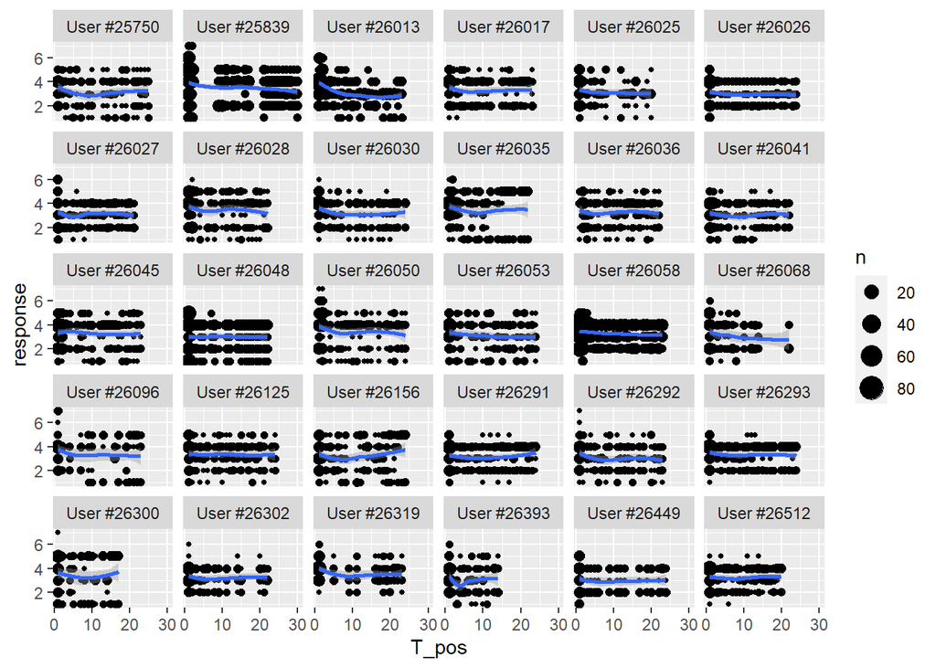

```r
ESM_2_1 %>%
  ggplot(aes(x = T_pos, y = response)) +
  geom_count() +
  geom_smooth() +
  facet_wrap(~Part)
```

# Reporting

We compute the mean response per participant and do correlations

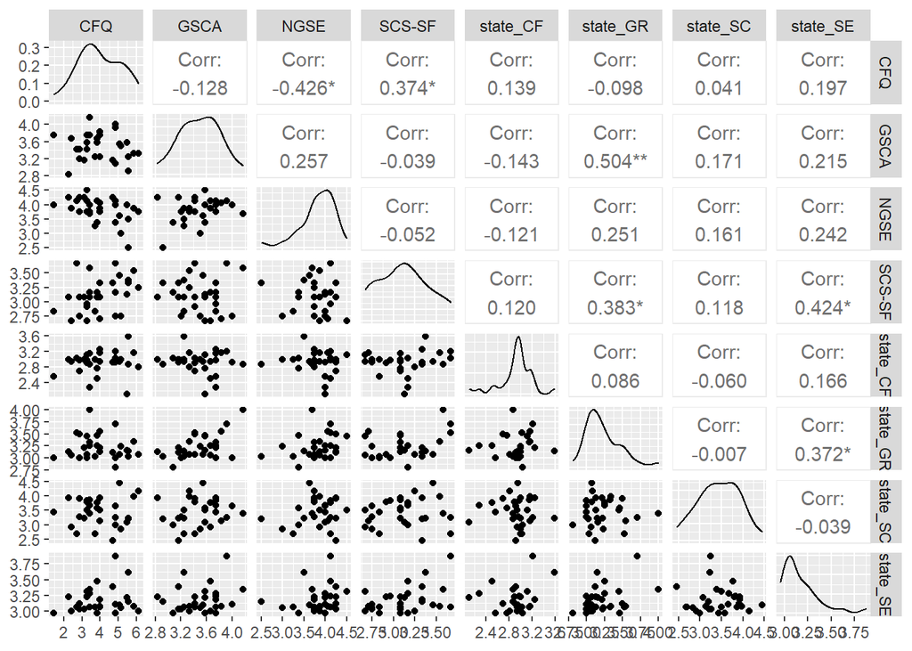

```r
ESM_2_1 %>%
  group_by(Part, Scale) %>%
  summarize(mean_resp = mean(response, na.rm = T)) %>%
  ungroup() %>%
  pivot_wider(names_from = Scale, values_from = mean_resp) %>%
  select(-Part) %>%
  GGally::ggpairs()
```

We do a mean response per Part, Scale and T_Scheduled and plot a time series. You need package mascutils from Github (restart your R session, before you install):

```r
devtools::install_github("schmettow/mascutils")
```

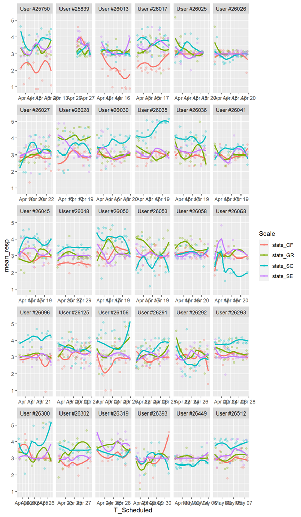

```r
ESM_2_1 %>%
  filter(str_detect(Scale, "^state")) %>%
  group_by(Part, Scale, T_Scheduled) %>%
  summarize(mean_resp = mean(response, na.rm = T)) %>%
  ungroup() %>%
  ggplot(aes(x = T_Scheduled,
             y = mean_resp,
             col = Scale)) +
  geom_jitter(alpha = .3) +
  geom_smooth(se = F) +
  facet_wrap(Part ~ ., scales = "free_x")
```